# Project 4: Causal Inference Algorithms Evaluation

Group 4: Zhenglei Chen, Jaival Desai, Qinzhe Hu, Levi Lee, Luyao Sun, Xinyi Wei

12/02/2020

## Setup

First, we set working directories as needed, install required libraries and import the data.

```r
df_high <- read.csv("../data/highDim_dataset.csv")
df_low <- read.csv("../data/lowDim_dataset.csv")
```

## Introduction

In this project, we are looking for the best algorithm for causal inference of propensity scores to see how close the estimated average treatment effects (ATEs) are to the true ATEs. For the estimation of propensity scores, we use regression trees. The algorithms we use to estimate ATEs in this project are stratification, regression adjustment and a combination of these two algorithms. We also compare the run times of different algorithms and propensity score estimations across both data sets.

## About the Data

There are two attached data sets for this project, named *highDim_data set* and *lowDim_data set*, which were from the Atlantic Causal Inference Conference (ACIC) Data Challenge. For the high dimensional data, there are 2000 observations, 185 variables ($V1$-$V185$), 1 treatment indicator variable ($A$) and 1 continuous response variable ($Y$). For the low dimensional data, there are 475 observations, 22 variables ($V1$-$V22$), 1 treatment indicator variable ($A$) and 1 continuous response variable ($Y$).

```
## [1] "High Dimensional Data"
```

```
##
##      0      1
## 0.5515 0.4485
```

```
## [1] "Low Dimensional Data"
```

```
##
##         0         1
## 0.7642105 0.2357895
```

## Background

### Classification/Regression Trees

The mathematical formula for a regression/classification tree is shown below.

$$\hat{f}(x) = \sum_{m = 1}^{M} c_{m}I\{x \in R_{m}\}$$

Here, $R_m$ is a specific region, $M$ is the number of regions, and $c_m$ is the value associated with a region.

The way regression trees work is that the space is split into multiple regions based on some set of decisions. This process keeps repeating until a stopping rule is applied. In regression, we use squared error loss to find the optimal tree model, but in classification, as with the case for estimating propensity scores, we use a measure of impurity. In our case, we use one called the Gini index. In R, we use a library called “rpart” to run the tree algorithm. This function allows users the choice of several hyperparameters, one of which is called “cp”, indicating the complexity of the model. This is a method of pruning the tree and allows the algorithm to determine if a split is worth pursuing. That is, we get more complex trees with lower values of “cp”.

The advantages of using a tree are interpretability and automated variable selection. It is easy to interpret because we can visualize the tree and the decision rules at each split. Additionally, these rules help to determine which variables are the most important when estimating the propensity scores.

### Propensity Scores

The propensity score is defined as follows:

$$e(x) = Pr(T = 1 | X = x), ~ 0 < e(x) < 1$$

Based on the formula above, given the (multiple) covariates ($x$), the propensity score is the probability that the observation is in the treatment group (in our case, observations where $A = 1$). Since, our data is based on observational studies, we can use propensity scores to make causal inferences.

### Average Treatment Effect (ATE)

The average treatment effect is defined as follows:

$$\Delta_{t} = E(Y_{1} - Y_{0} | T = 1)$$

ATE is defined as the difference in the average outcomes between observations assigned to treatment group and the control group. This allows us to measure the effect a treatment had on each group.

## Cross-Validation

We perform five fold cross-validation for the high dimension and low dimension data sets. The main objective of the cross validation is to tune the “cp” parameter to avoid overfitting.

### Step 1: Set Controls and Establish Hyperparameters

We set up the controls to start the the cross validation process

```r
K <- 5  # number of CV folds
sample.reweight <- TRUE # run sample reweighting in model training

# setting the following to false loads data generated from a previous run
# this data is the same in each run due to a set seed

run.cv.trees_high <- FALSE # run cross-validation on the training set for trees on high dim data

run.cv.trees_low <- FALSE # run cross-validation on the training set for trees on low dim data
```

We choose a set of “cp” values here to cross validate in order to find the optimal “cp” value for each data set; here we choose to do powers of two.

```r
# hyperparameters for trees
hyper_grid_trees <- expand.grid(
  cp = c(2^(0), 2^(-1), 2^(-2), 2^(-3), 2^(-4),
         2^(-5), 2^(-6), 2^(-7), 2^(-8), 2^(-9),
         2^(-10), 2^(-11), 2^(-12), 2^(-13), 2^(-14),
         2^(-15), 2^(-16), 2^(-17), 0, -2^(0))
)
```

### Step 2: Cross-Validate the Hyperparameters

We source the library functions that we created to help cross validate the “cp” hyperparamter.

```r
# data pre-processing

# features are the predictors: V1 - Vp
# column 1 is the response Y
# column 2 is the treatment A

feature_train_high = df_high[, -1:-2]
label_train_high = df_high[, 2]

feature_train_low = df_low[, -1:-2]
label_train_low = df_low[, 2]
```

#### High Dimensional Data

We run the cross validation algorithm on the high dimensional data.

```r
set.seed(5243)

if(run.cv.trees_high){
  res_cv_trees_high <- matrix(0, nrow = nrow(hyper_grid_trees), ncol = 4)
  for(i in 1:nrow(hyper_grid_trees)){
    cat("complexity = ", hyper_grid_trees$cp[i], "\n", sep = "")
    res_cv_trees_high[i,] <- cv.function(features = feature_train_high,
                                         labels = label_train_high,
                                         cp = hyper_grid_trees$cp[i],
                                         K, reweight = sample.reweight)
  save(res_cv_trees_high, file = "../output/res_cv_trees_high.RData")
  }
} else{
  load("../output/res_cv_trees_high.RData")
}
```

#### Low Dimensional Data

```r
set.seed(5243)

if(run.cv.trees_low){
  res_cv_trees_low <- matrix(0, nrow = nrow(hyper_grid_trees), ncol = 4)
  for(i in 1:nrow(hyper_grid_trees)){
    cat("complexity = ", hyper_grid_trees$cp[i], "\n", sep = "")
    res_cv_trees_low[i,] <- cv.function(features = feature_train_low,
                                        labels = label_train_low,
                                        cp = hyper_grid_trees$cp[i],
                                        K, reweight = sample.reweight)
  save(res_cv_trees_low, file="../output/res_cv_trees_low.RData")
  }
}else{
  load("../output/res_cv_trees_low.RData")
}
```

### Step 3: Visualize CV Error and AUC

After cross validating, we obtain the mean error and the AUC values for each potential “cp” value for both data sets. We display these values and associated standard errors in the plots below.

Because of the imbalances in the groups for both datasets, we choose to not only weigh our observations, but to also focus on mean AUC when selecting the optimal hyperparameter.

#### High Dimensional Data

Based on the plots and table below, we find that the model with the highest mean AUC value has a “cp” value of $2^{-7}$.

```r
# create data frame to organize results
res_cv_trees_high <- as.data.frame(res_cv_trees_high)
colnames(res_cv_trees_high) <- c("mean_error", "sd_error", "mean_AUC", "sd_AUC")
cv_results_trees_high = data.frame(hyper_grid_trees, res_cv_trees_high)

# look at top 5 models with highest AUC
cv_results_trees_high[order(cv_results_trees_high$mean_AUC, decreasing = TRUE), ][1:5, ]
```

|  | cp | mean_error | sd_error | mean_AUC | sd_AUC |
| --- | --- | --- | --- | --- | --- |
| 8 | 7.812500e-03 | 0.4360668 | 0.03628091 | 0.5674343 | 0.03056252 |
| 6 | 3.125000e-02 | 0.4382665 | 0.02892494 | 0.5670732 | 0.03043522 |
| 7 | 1.562500e-02 | 0.4443627 | 0.01912652 | 0.5554088 | 0.01920727 |
| 5 | 6.250000e-02 | 0.4519064 | 0.01953579 | 0.5466031 | 0.02064263 |
| 18 | 7.629395e-06 | 0.4633120 | 0.01383644 | 0.5429351 | 0.02240466 |

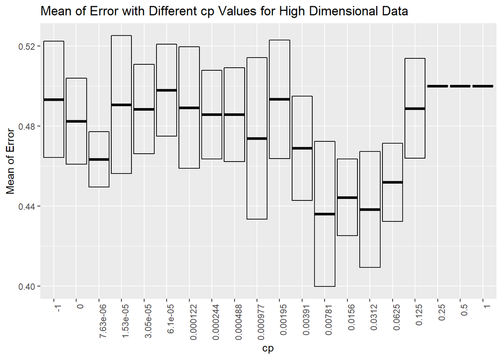

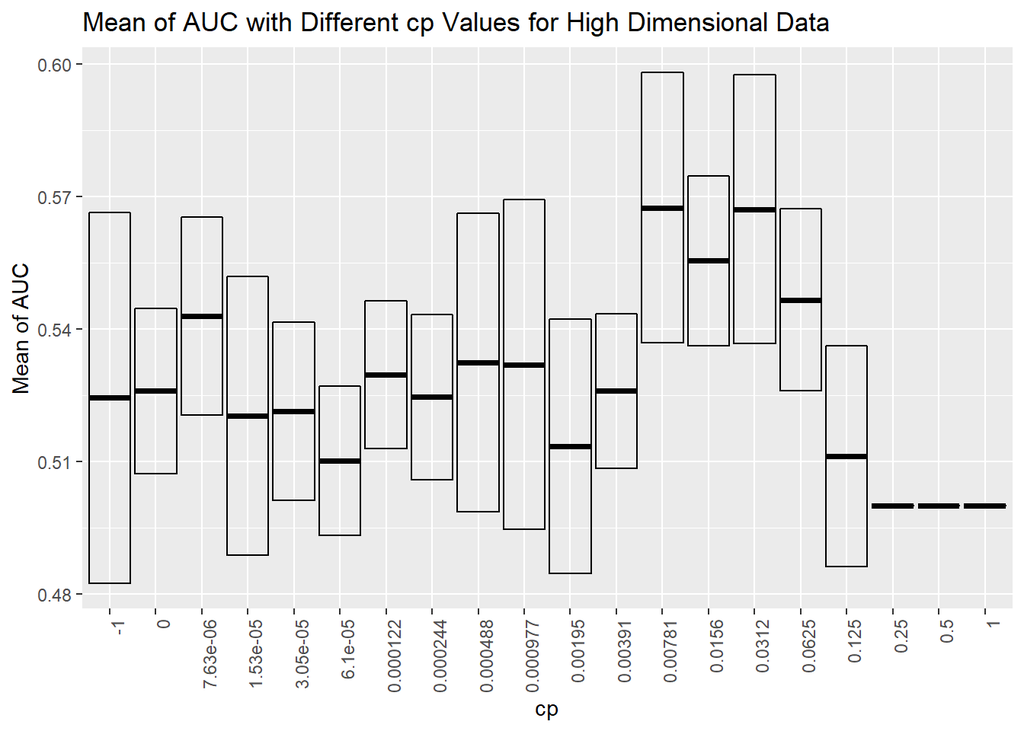

```r
best_cp_high <- cv_results_trees_high$cp[cv_results_trees_high$mean_AUC ==
                                           max(cv_results_trees_high$mean_AUC)]

best_cp_high
```

```
## [1] 0.0078125
```

#### Low Dimensional Data

```r
# create data frame to organize results
res_cv_trees_low <- as.data.frame(res_cv_trees_low)
colnames(res_cv_trees_low) <- c("mean_error", "sd_error", "mean_AUC", "sd_AUC")
cv_results_trees_low = data.frame(hyper_grid_trees, res_cv_trees_low)

# look at top 5 models with lowest AUC
cv_results_trees_low[order(cv_results_trees_low$mean_AUC, decreasing = TRUE), ][1:5, ]
```

|  | cp | mean_error | sd_error | mean_AUC | sd_AUC |
| --- | --- | --- | --- | --- | --- |
| 18 | 7.629395e-06 | 0.3924126 | 0.07329778 | 0.6403787 | 0.08438962 |
| 3 | 2.500000e-01 | 0.3653965 | 0.06938198 | 0.6346035 | 0.06938198 |
| 4 | 1.250000e-01 | 0.3686625 | 0.05437925 | 0.6313375 | 0.05437925 |
| 5 | 6.250000e-02 | 0.3688654 | 0.03598451 | 0.6275346 | 0.03449488 |
| 6 | 3.125000e-02 | 0.3707763 | 0.04889355 | 0.6200507 | 0.04439815 |

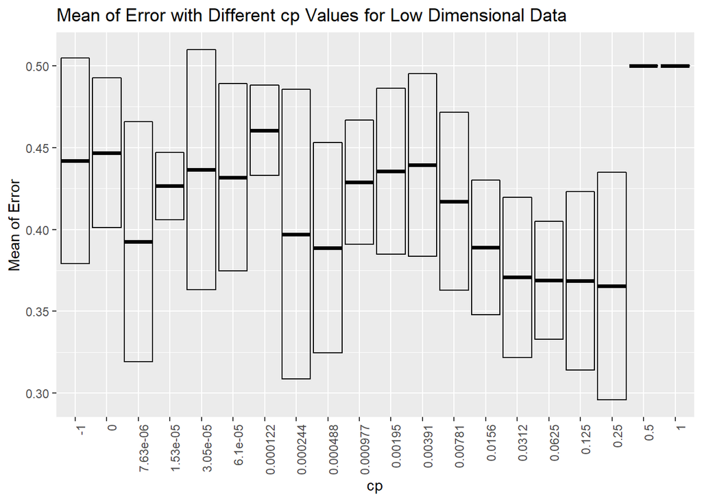

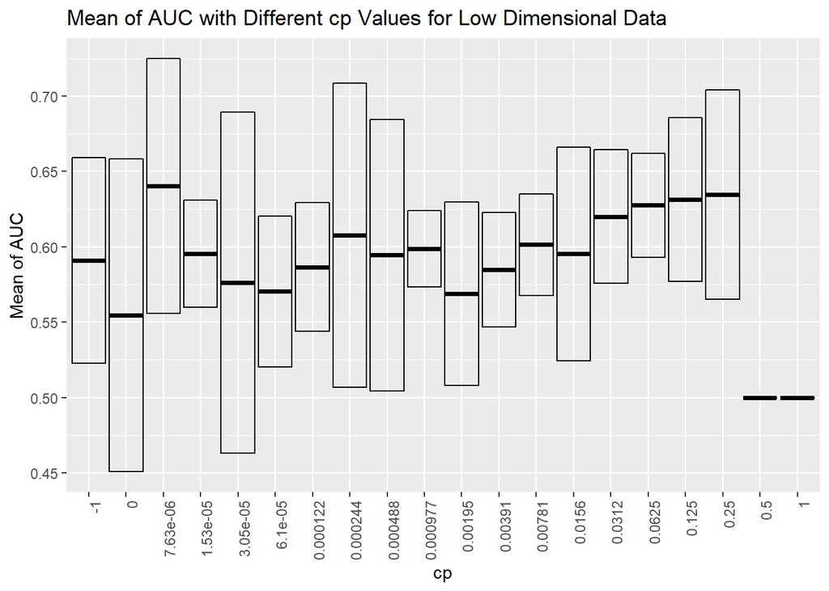

```r
best_cp_low <- cv_results_trees_low$cp[cv_results_trees_low$mean_AUC ==
                                           max(cv_results_trees_low$mean_AUC)]

best_cp_low
```

```
## [1] 7.629395e-06
```

## Propensity Score Estimation

```r
# imbalanced dataset requires weights
# to be used in the trained model

weights_high <- rep(NA, length(df_high$A))
for (v in unique(df_high$A)){
  weights_high[df_high$A == v] = 0.5 * length(df_high$A) / length(df_high$A[df_high$A == v])
}


weights_low <- rep(NA, length(df_low$A))
for (v in unique(df_low$A)){
  weights_low[df_low$A == v] = 0.5 * length(df_low$A) / length(df_low$A[df_low$A == v])
}
```

#### High Dimensional Data

```r
start.time_propensity_score_high <- Sys.time()

# create tree model for high dimensional data with best cp parameter
tree_high <- rpart(A ~ . - Y, method = "class", data = df_high, cp = best_cp_high)

# calculate propensity scores
prop_score_high <- predict(tree_high, newdata = df_high[, -2], type = "prob")[, 2]

end.time_propensity_score_high <- Sys.time()
time_propensity_score_high <- end.time_propensity_score_high - start.time_propensity_score_high
time_propensity_score_high
```

```
## Time difference of 1.12901 secs
```

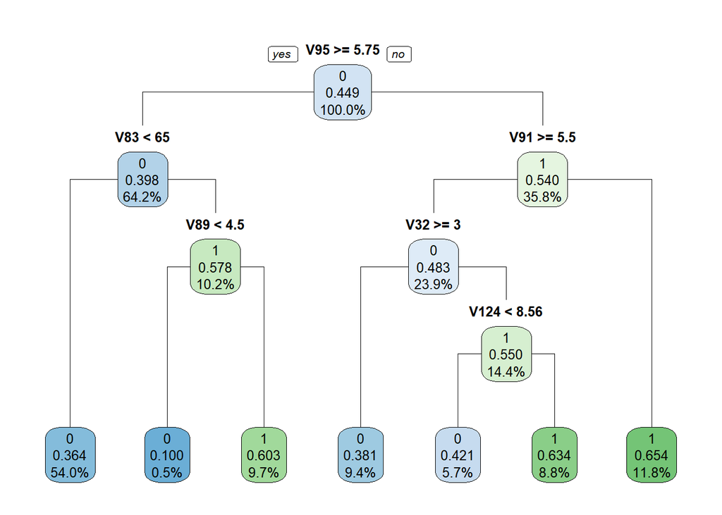

#### Low Dimensional Data

```r
start.time_propensity_score_low <- Sys.time()

# create tree model for low dimensional data with best cp parameter
tree_low <- rpart(A ~ . - Y, method = "class", data = df_low, cp = best_cp_low)

# calculate propensity scores
prop_score_low <- predict(tree_low, newdata = df_low[, -2], type = "prob")[, 2]

end.time_propensity_score_low <- Sys.time()
time_propensity_score_low <- end.time_propensity_score_low - start.time_propensity_score_low
time_propensity_score_low
```

```
## Time difference of 0.03989577 secs
```

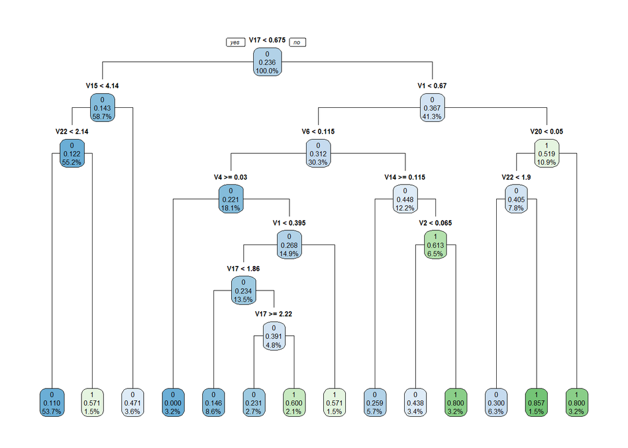

## ATE Estimation

With the estimated propensity scores on hand, we propose, explain, and discuss the pros and cons of three different ATE estimation algorithms: stratification, regression adjustment, and stratification plus regression adjustment together.

### Stratification

In the stratification method, we are trying to achieve groups where propensity scores hold approximately. For choosing number of strata, $K$, five ($5$) was advocated by Rosenbaum and Rubin (1984). However, in our case, choosing $K = 5$ will lead to empty stratum for both high and low dimensional data.

```r
# when K = 5, the second stratus of high and low dimensional data are both empty
# but we need to make sure each stratum consists at least one object

summary_high_k5
```

| A | stratum | n | prop | avg_y |
| --- | --- | --- | --- | --- |
| 0 | 1 | 9 | 0.0045 | -1.556754 |
| 1 | 1 | 1 | 0.0005 | 3.448809 |
| 0 | 2 | 0 | 0.0000 | 0.000000 |
| 1 | 2 | 0 | 0.0000 | 0.000000 |
| 0 | 3 | 805 | 0.4025 | -13.679379 |
| 1 | 3 | 465 | 0.2325 | -16.168680 |
| 0 | 4 | 207 | 0.1035 | -7.569860 |
| 1 | 4 | 276 | 0.1380 | -9.608015 |
| 0 | 5 | 82 | 0.0410 | -4.527548 |
| 1 | 5 | 155 | 0.0775 | -6.089711 |

```r
summary_low_k5
```

| A | stratum | n | prop | avg_y |
| --- | --- | --- | --- | --- |
| 0 | 1 | 15 | 0.03157895 | 18.25654 |
| 1 | 1 | 0 | 0.00000000 | 0.00000 |
| 0 | 2 | 0 | 0.00000000 | 0.00000 |
| 1 | 2 | 0 | 0.00000000 | 0.00000 |
| 0 | 3 | 262 | 0.55157895 | 15.34302 |
| 1 | 3 | 34 | 0.07157895 | 18.68881 |
| 0 | 4 | 51 | 0.10736842 | 19.22334 |
| 1 | 4 | 19 | 0.04000000 | 22.18808 |
| 0 | 5 | 35 | 0.07368421 | 19.03667 |
| 1 | 5 | 59 | 0.12421053 | 22.63080 |

Therefore we choose $K = 3$ strata, which is the highest value of $K$ that do not produce empty stratum. Then we can estimate ATE between treated and untreated subgroups by following formula:

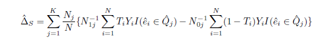

where $K$ is the number of strata, $\hat{e}$ is the estimated propensity score, $Y$ is the response for each observation, and $T$ is the treatment variable (either $0$ or $1$). $N_j$ is the number of individuals in stratum $j$. $N_{1j}$ is the number of “treated” individuals in stratum $j$, while $N_{0j}$ is the number of “controlled” individuals in stratum $j$. $\hat{Q_j} = (\hat{q_{j-1}}, \hat{q_j}]$ where $\hat{q_j}$ is the $j$th sample quantile of the estimated propensity scores.

The advantage of stratification is that it controls systematic differences between the control and treated groups. However, as we mentioned earlier, stratification has imbalance issues in each stratum. In some extreme cases, where some strata may contain subjects from only the treated group or control group, it becomes impossible to estimate treatment effect. What’s more, Lunceford and Davidian (2004) demonstrated that stratification results in estimates of average treatment effects with greater bias than does a variety of weighted estimators.

```r
K = 3
strata <- seq(0, 1, by = 1/K)
```

#### High Dimensional Data

```r
start.time_stratification_high <- Sys.time()

df_high <- cbind(df_high, prop_score_high)
stratum_values_high <- rep(NA, length(strata))

for (i in 1:length(strata)){
  stratum_values_high[i] <- quantile(prop_score_high, strata[i])
}

# values of strata for high data
stratum_values_high
```

```
## [1] 0.1000000 0.3635523 0.4210526 0.6540084
```

```r
df_high$stratum_class_high <- rep(NA, nrow(df_high))

# assign stratum class to each observation
for (i in 1:nrow(df_high)){
  if ((stratum_values_high[1] <= df_high$prop_score_high[i]) &
      (df_high$prop_score_high[i] < stratum_values_high[2])) {
    df_high$stratum_class_high[i] <- 1
  } else if ((stratum_values_high[2] <= df_high$prop_score_high[i]) &
             (df_high$prop_score_high[i] < stratum_values_high[3])) {
    df_high$stratum_class_high[i] <- 2
  } else if ((stratum_values_high[3] <= df_high$prop_score_high[i]) &
             (df_high$prop_score_high[i] <= stratum_values_high[4])) {
    df_high$stratum_class_high[i] <- 3
  }
}

summary_high = expand.grid(
  A = c(0, 1),
  stratum = seq(1, K, by = 1),
  n = NA,
  prop = NA,
  avg_y = NA
)

for (i in 1:nrow(summary_high)) {
  subset <- df_high[(df_high$A == summary_high$A[i]) &
                      (df_high$stratum_class_high == summary_high$stratum[i]), ]
  summary_high$n[i] = nrow(subset)
  summary_high$prop[i] = summary_high$n[i]/nrow(df_high)
  summary_high$avg_y[i] = mean(subset$Y)
}


for (i in 1:nrow(summary_high)) {
  if (is.nan(summary_high$avg_y[i]) == TRUE) {
    summary_high$avg_y[i] <- 0
  }
}

# this table records the mean response in each stratum; needed for stratification
summary_high
```

| A | stratum | n | prop | avg_y |
| --- | --- | --- | --- | --- |
| 0 | 1 | 9 | 0.0045 | -1.556754 |
| 1 | 1 | 1 | 0.0005 | 3.448809 |
| 0 | 2 | 805 | 0.4025 | -13.679379 |
| 1 | 2 | 465 | 0.2325 | -16.168680 |
| 0 | 3 | 289 | 0.1445 | -6.706643 |
| 1 | 3 | 431 | 0.2155 | -8.342732 |

```r
stratum_prop_high <- summary_high %>% group_by(stratum) %>% summarise(sum = sum(n)/nrow(df_high))
# this table records the proportions for each stratum; also needed for stratification
stratum_prop_high
```

| stratum | sum |
| --- | --- |
| 1 | 0.005 |
| 2 | 0.635 |
| 3 | 0.360 |

```r
ATE_stratification_high = stratum_prop_high$sum[1]*(summary_high$avg_y[2] - summary_high$avg_y[1]) +
  stratum_prop_high$sum[2]*(summary_high$avg_y[4] - summary_high$avg_y[3]) +
  stratum_prop_high$sum[3]*(summary_high$avg_y[6] - summary_high$avg_y[5])

ATE_stratification_high
```

```
## [1] -2.14467
```

```r
end.time_stratification_high <- Sys.time()
time_stratification_high <- end.time_stratification_high - start.time_stratification_high
time_stratification_high
```

```
## Time difference of 0.209439 secs
```

We find that the ATE for the high dimensional dataset was -2.145 with a run time of 0.209 seconds.

#### Low Dimensional Data

```r
start.time_stratification_low <- Sys.time()

df_low <- cbind(df_low, prop_score_low)
stratum_values_low <- rep(NA, length(strata))

for (i in 1:length(strata)){
  stratum_values_low[i] <- quantile(prop_score_low, strata[i])
}

# values of strata for low data
stratum_values_low
```

```
## [1] 0.0000000 0.1098039 0.2307692 0.8571429
```

```r
df_low$stratum_class_low <- rep(NA, nrow(df_low))

# assign stratum class to each observation
for (i in 1:nrow(df_low)){
  if ((stratum_values_low[1] <= df_low$prop_score_low[i]) &
      (df_low$prop_score_low[i] < stratum_values_low[2])) {
    df_low$stratum_class_low[i] <- 1
  } else if ((stratum_values_low[2] <= df_low$prop_score_low[i]) &
             (df_low$prop_score_low[i] < stratum_values_low[3])) {
    df_low$stratum_class_low[i] <- 2
  } else if ((stratum_values_low[3] <= df_low$prop_score_low[i]) &
             (df_low$prop_score_low[i] <= stratum_values_low[4])) {
    df_low$stratum_class_low[i] <- 3
  }
}


summary_low = expand.grid(
  A = c(0, 1),
  stratum = seq(1, K, by = 1),
  n = NA,
  prop = NA,
  avg_y = NA
)

for (i in 1:nrow(summary_low)) {
  subset <- df_low[(df_low$A == summary_low$A[i]) &
                     (df_low$stratum_class_low == summary_low$stratum[i]), ]
  summary_low$n[i] = nrow(subset)
  summary_low$prop[i] = summary_low$n[i]/nrow(df_low)
  summary_low$avg_y[i] = mean(subset$Y)
}


for (i in 1:nrow(summary_low)) {
  if (is.nan(summary_low$avg_y[i]) == TRUE) {
    summary_low$avg_y[i] <- 0
  }
}

# this table records the mean response in each stratum; needed for stratification
summary_low
```

| A | stratum | n | prop | avg_y |
| --- | --- | --- | --- | --- |
| 0 | 1 | 15 | 0.03157895 | 18.25654 |
| 1 | 1 | 0 | 0.00000000 | 0.00000 |
| 0 | 2 | 262 | 0.55157895 | 15.34302 |
| 1 | 2 | 34 | 0.07157895 | 18.68881 |
| 0 | 3 | 86 | 0.18105263 | 19.14737 |
| 1 | 3 | 78 | 0.16421053 | 22.52296 |

```r
stratum_prop_low <- summary_low %>% group_by(stratum) %>% summarise(sum = sum(n)/nrow(df_low))
# this table records the proportions for each stratum; also needed for stratification
stratum_prop_low
```

| stratum | sum |
| --- | --- |
| 1 | 0.03157895 |
| 2 | 0.62315789 |
| 3 | 0.34526316 |

```r
ATE_stratification_low = stratum_prop_low$sum[1]*(summary_low$avg_y[2] - summary_low$avg_y[1]) +
  stratum_prop_low$sum[2]*(summary_low$avg_y[4] - summary_low$avg_y[3]) +
  stratum_prop_low$sum[3]*(summary_low$avg_y[6] - summary_low$avg_y[5])

ATE_stratification_low
```

```
## [1] 2.673899
```

```r
end.time_stratification_low <- Sys.time()
time_stratification_low <- end.time_stratification_low - start.time_stratification_low
time_stratification_low
```

```
## Time difference of 0.1056862 secs
```

We find that the ATE for the low dimensional dataset was 2.674 with a run time of 0.106 seconds.

### Regression Adjustment

In this method, we regress the response variable ($Y$) with the treatment variable ($A$) and the propensity scores estimated using our model above, in this case, trees. The estimated coefficient of the treatment variable ($A$) is then an estimate of the ATE.

D’Agostino (1998) and Austin (2011) compare regression adjustment with more traditional propensity score methods. One of the main advantages of the regression adjustment is in its simplicity in execution, in which one performs a somewhat basic linear regression model on two covariates and one response variable.

However, depending on the size of the dataset, this may run into computation issues as linear regression involves finding the inverse of a matrix. Additionally, regression adjustment may also not be helpful in cases where there is a strong separation between the two groups.

No such issues were present in this setup given that both datasets had a relatively small number of observations and there is no clear separation between the two groups, as shown in the residual plots below.

#### High Dimensional Data

```r
start.time_regression_adjustment_high <- Sys.time()

ps_RA_high <- predict(tree_high, df_high, type = "prob")
high_data_ps <- cbind(ps_RA_high, df_high)
pred_high <- lm(Y ~ A + ps_RA_high, data = high_data_ps)
summary(pred_high)
```

```
##
## Call:
## lm(formula = Y ~ A + ps_RA_high, data = high_data_ps)
##
## Residuals:
##      Min       1Q   Median       3Q      Max
## -17.4713  -3.4878  -0.6694   2.7522  30.0897
##
## Coefficients: (1 not defined because of singularities)
##             Estimate Std. Error t value Pr(>|t|)
## (Intercept)   5.9564     0.6207   9.596   <2e-16 ***
## A            -2.5271     0.2569  -9.836   <2e-16 ***
## ps_RA_high0 -30.5718     1.0322 -29.617   <2e-16 ***
## ps_RA_high1       NA         NA      NA       NA
## ---
## Signif. codes:  0 '***' 0.001 '**' 0.01 '*' 0.05 '.' 0.1 ' ' 1
##
## Residual standard error: 5.535 on 1997 degrees of freedom
## Multiple R-squared:  0.3068, Adjusted R-squared:  0.3061
## F-statistic: 441.8 on 2 and 1997 DF,  p-value: < 2.2e-16
```

```r
ATE_regression_adjustment_high = pred_high$coefficients[2]
ATE_regression_adjustment_high
```

```
##         A
## -2.527116
```

```r
end.time_regression_adjustment_high <- Sys.time()
time_regression_adjustment_high <- end.time_regression_adjustment_high -
  start.time_regression_adjustment_high
time_regression_adjustment_high
```

```
## Time difference of 0.03789902 secs
```

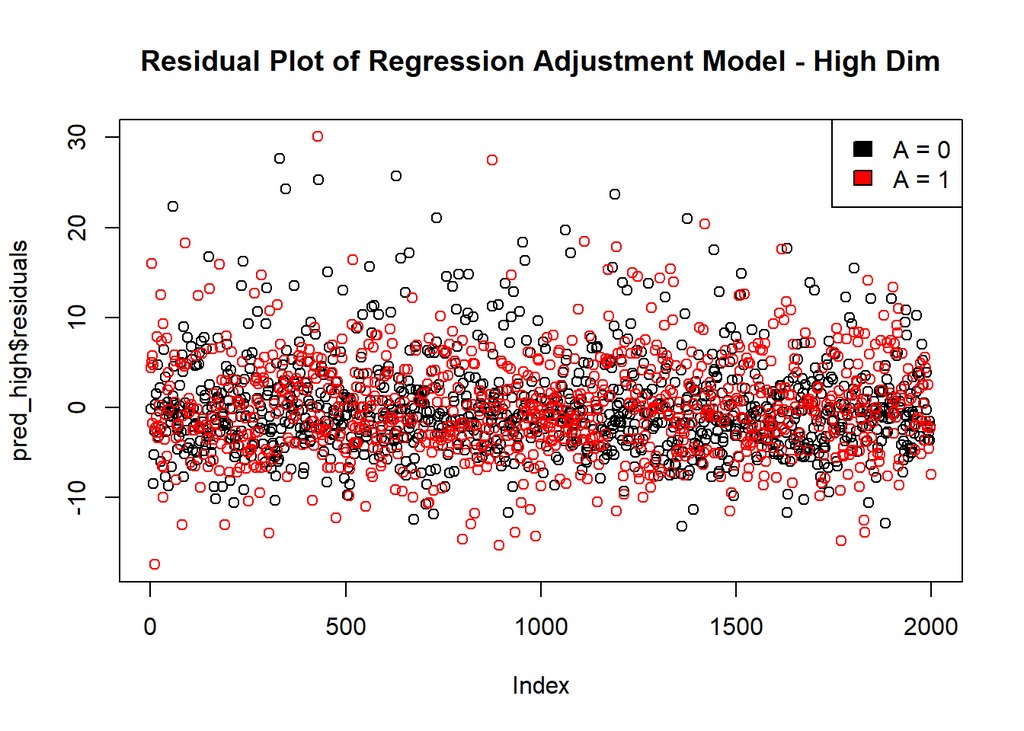

We find that the ATE for the high dimensional dataset was -2.527 with a run time of 0.038 seconds.

#### Low Dimensional Data

```r
start.time_regression_adjustment_low <- Sys.time()

ps_RA_low <- predict(tree_low, df_low, type = "prob")
low_data_ps <- cbind(ps_RA_low, df_low)
pred_low <- lm(Y ~ A + ps_RA_low, data = low_data_ps)
summary(pred_low)
```

```
##
## Call:
## lm(formula = Y ~ A + ps_RA_low, data = low_data_ps)
##
## Residuals:
##      Min       1Q   Median       3Q      Max
## -11.5153  -2.6807  -0.5655   1.8184  26.9282
##
## Coefficients: (1 not defined because of singularities)
##             Estimate Std. Error t value Pr(>|t|)
## (Intercept)  22.5693     0.8535  26.445  < 2e-16 ***
## A             3.0532     0.5089   5.999 3.95e-09 ***
## ps_RA_low0   -7.5200     1.0017  -7.507 3.04e-13 ***
## ps_RA_low1        NA         NA      NA       NA
## ---
## Signif. codes:  0 '***' 0.001 '**' 0.01 '*' 0.05 '.' 0.1 ' ' 1
##
## Residual standard error: 4.055 on 472 degrees of freedom
## Multiple R-squared:  0.2829, Adjusted R-squared:  0.2798
## F-statistic: 93.08 on 2 and 472 DF,  p-value: < 2.2e-16
```

```r
ATE_regression_adjustment_low = pred_low$coefficients[2]
ATE_regression_adjustment_low
```

```
##       A
## 3.05324
```

```r
end.time_regression_adjustment_low <- Sys.time()
time_regression_adjustment_low <- end.time_regression_adjustment_low -
  start.time_regression_adjustment_low
time_regression_adjustment_low
```

```
## Time difference of 0.01795292 secs
```

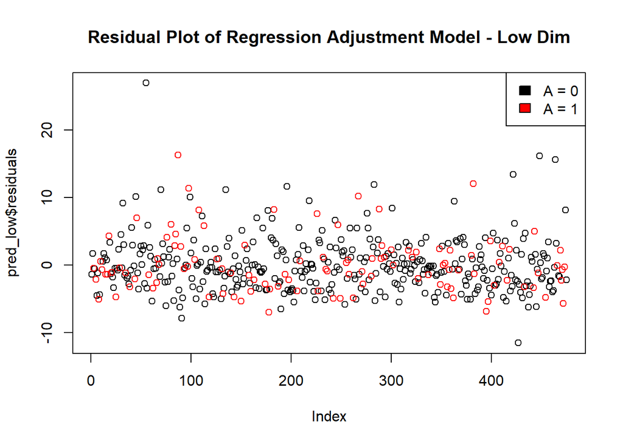

We find that the ATE for the low dimensional dataset was 3.0532404 with a run time of 0.0179529190063477 seconds.

### Stratification and Regression Adjustment

In this last method, we will combine the first two methods together. In the same way as stratification, we split the datasets into $K = 3$ strata. The choice of $K = 3$ is again because it was the highest value of $K$ that did not give us an empty stratum. Within each stratum, we perform regression adjustment by regressing the response variable ($Y$) with the treatment variable ($A$) and the estimated propensity scores. We then have three coefficients for the variable A, one for each regression model. We then take a weighted average of these coefficients, with the weights relative to the population of each strata.

As D’Agostino (1998) notes, stratification combined with regression adjustment helps to reduce the bias in the treatment effect if the treatment groups are parallel and performs much better than propensity score matching alone. However, this method has the same drawbacks as stated in both stratification and regression adjustment.

| A | stratum | n | prop | avg_y |
| --- | --- | --- | --- | --- |
| 0 | 1 | 9 | 0.0045 | -1.556754 |
| 1 | 1 | 1 | 0.0005 | 3.448809 |
| 0 | 2 | 805 | 0.4025 | -13.679379 |
| 1 | 2 | 465 | 0.2325 | -16.168680 |
| 0 | 3 | 289 | 0.1445 | -6.706643 |
| 1 | 3 | 431 | 0.2155 | -8.342732 |

| A | stratum | n | prop | avg_y |
| --- | --- | --- | --- | --- |
| 0 | 1 | 15 | 0.03157895 | 18.25654 |
| 1 | 1 | 0 | 0.00000000 | 0.00000 |
| 0 | 2 | 262 | 0.55157895 | 15.34302 |
| 1 | 2 | 34 | 0.07157895 | 18.68881 |
| 0 | 3 | 86 | 0.18105263 | 19.14737 |
| 1 | 3 | 78 | 0.16421053 | 22.52296 |

In particular, we see very imbalanced groups within each strata, as shown in the summary tables from the stratification method shown above, which may end up increasing the bias in our estimate of the ATE instead. We would be cautious of advocating for this method even if the ATE estimate was accurate.

#### High Dimensional Data

```r
start.time_stratification_regression_adjustment_high <- Sys.time()

lm_beta_high <- rep(NA, K)

for (i in 1:K){
  subset <- df_high[df_high$stratum_class_high == i, ]

  if (nrow(subset) == 0) {
    # if the stratum is empty, let the coefficient for A automatically be 0
    lm_beta_high[i] <- 0
  } else if (sum(subset$prop_score_high) == 0) {
    # if the propensity scores in the stratum are all 0,
    # let the coefficient for A automatically be 0
    lm_beta_low[i] <- 0
  } else {
    # otherwise, run a linear model on the subset
    lm <- lm(Y ~ A + prop_score_high, data = subset)
    lm_beta_high[i] <- as.numeric(lm$coefficients[2])
  }
}

lm_beta_high
```

```
## [1]  5.005563 -2.486942 -2.637645
```

```r
ATE_stratification_regression_adjustment_high <- stratum_prop_high$sum[1]*lm_beta_high[1] +
  stratum_prop_high$sum[2]*lm_beta_high[2] +
  stratum_prop_high$sum[3]*lm_beta_high[3]

ATE_stratification_regression_adjustment_high
```

```
## [1] -2.503732
```

```r
end.time_stratification_regression_adjustment_high <- Sys.time()

time_stratification_regression_adjustment_high <-
  end.time_stratification_regression_adjustment_high -
  start.time_stratification_regression_adjustment_high

time_stratification_regression_adjustment_high
```

```
## Time difference of 0.03889704 secs
```

We find that the ATE for the high dimensional dataset was -2.504 with a run time of 0.039 seconds.

#### Low Dimensional Data

```r
start.time_stratification_regression_adjustment_low <- Sys.time()

lm_beta_low <- rep(NA, K)

for (i in 1:K){
  subset <- df_low[df_low$stratum_class_low == i, ]

  if (nrow(subset) == 0) {
    # if the stratum is empty, let the coefficient for A automatically be 0
    lm_beta_low[i] <- 0
  } else if (sum(subset$prop_score_low) == 0) {
    # if the propensity scores in the stratum are all 0
    # let the coefficient for A automatically be 0
    lm_beta_low[i] <- 0
  } else {
    # otherwise, run a linear model on the subset
    lm <- lm(Y ~ A + prop_score_low, data = subset)
    lm_beta_low[i] <- as.numeric(lm$coefficients[2])
  }
}

lm_beta_low
```

```
## [1] 0.000000 3.264136 2.863805
```

```r
ATE_stratification_regression_adjustment_low <- stratum_prop_low$sum[1]*lm_beta_low[1] +
  stratum_prop_low$sum[2]*lm_beta_low[2] +
  stratum_prop_low$sum[3]*lm_beta_low[3]

ATE_stratification_regression_adjustment_low
```

```
## [1] 3.022839
```

```r
end.time_stratification_regression_adjustment_low <- Sys.time()

time_stratification_regression_adjustment_low <-
  end.time_stratification_regression_adjustment_low -
  start.time_stratification_regression_adjustment_low

time_stratification_regression_adjustment_low
```

```
## Time difference of 0.02892399 secs
```

We find that the ATE for the low dimensional dataset was 3.023 with a run time of 0.029 seconds.

## Results

We compare the accuracy and performance of the three ATE Estimation procedures below.

### ATE Results

We are provided the true ATE values of $-3$ for the high dimensional data and $2.5$ for the low dimensional data.

```
##                                        High Dimensional Data
## True                                               -3.000000
## Stratification                                     -2.144670
## Regression Adjustment                              -2.527116
## Stratification + Regression Adjustment             -2.503732
##                                        Low Dimensional Data
## True                                               2.500000
## Stratification                                     2.673899
## Regression Adjustment                              3.053240
## Stratification + Regression Adjustment             3.022839
```

From the table above, we see that regression adjustment performed the best for the high dimensional data and stratification performed the best for the low dimensional data.

### Run Time Results

```
##                                        High Dimensional Data
## Propensity Score Estimation                       1.12900996
## Stratification                                    0.20943904
## Regression Adjustment                             0.03789902
## Stratification + Regression Adjustment            0.03889704
##                                        Low Dimensional Data
## Propensity Score Estimation                      0.03989577
## Stratification                                   0.10568619
## Regression Adjustment                            0.01795292
## Stratification + Regression Adjustment           0.02892399
```

Given the nature of trees, propensity score estimations are quickly calculated once we have the proper hyperparamters selected from cross-validation–even for the high dimensional data, propensity score estimations did not take more than two seconds.

It is also no surprise that, given the sizes of our two datasets, that regression adjustment was the fastest method. However, with larger datasets with more observations, this may not be the case. Stratification took the longest time, mainly due to the many intermediate calculations requited. Lastly, the combination method of both stratification and regression adjustment had a run time between the two former methods.

However, we want to note that this .Rmd file was knitted using a computer with a NVMe SAMSUNG SSD with 16 GB RAM. Run times may vary from device to device and with each iteration. Descriptions of run times are based on average run times we saw through numerous iterations.

## Conclusion

Overall, we believe that using classification/regression trees for propensity scores was not the ideal approach for either dataset. While we cross-validated the complexity hyperparameter, cp, to help avoid with overfitting, our models for both the high dimensional and low dimensional datasets ended up estimating the same propensity score value for over half of the entire dataset. This would not be a very helpful model in differentiating our observations and of course affect our ATE estimations regardless of the method used.

We see this most prominently in stratification, in which different values of $K$, that is, the number of strata, resulted in an empty stratum in our results. Even after choosing a value of $K$ which would present no empty strata, we saw that each stratum tend to have imbalanced classes. In the case of the low dimensional dataset, one stratum only consisted of observations from the control group. These complications may explain why the stratification plus regression adjustment method would not have performed the best.

However, the results were relatively consistent among all three methods–there were no large deviations from the true value. In particular, the ATE for stratification was actually quite close to the true value for the low dimensional data. Additionally, compared to other methods, we note the relative ease of interpretation and fast run times for not only the propensity score estimations but also for the ATE estimations as well. While we may not advocate for these estimation methods for their accuracy (and validity in certain cases), but these methods here show a fast and easy way to get a general sense of the average treatment effect.

## References

- Atkinson, Beth. “Recursive Partitioning And Regression Trees.” R Documentation, DataCamp, www.rdocumentation.org/packages/rpart/versions/4.1-15/topics/rpart.
- Austin, Peter C. 2011. “An Introduction to Propensity Score Methods for Reducing the Effects of Confounding in Observational Studies.” Multivariate Behavioral Research 46 (3): 399–424.
- Chan, David & Ge, Rong & Gershony, Ori & Hesterberg, Tim & Lambert, Diane. (2010). Evaluating online ad campaigns in a pipeline: Causal models at scale. Proceedings of the ACM SIGKDD International Conference on Knowledge Discovery and Data Mining. 7-16. 10.1145/1835804.1835809.
- D’Agostino RB Jr. Propensity score methods for bias reduction in the comparison of a treatment to a non-randomized control group. Stat Med. 1998 Oct 15;17(19):2265-81. doi: 10.1002/(sici)1097-0258(19981015)17:19<2265::aid-sim918>3.0.co;2-b. PMID: 9802183.
- Hastie, Trevor,, Robert Tibshirani, and J. H Friedman. The Elements of Statistical Learning: Data Mining, Inference, and Prediction. 2nd ed. New York: Springer, 2009. Print.
- Lunceford, Jared K, and Marie Davidian. 2004. “Stratification and Weighting via the Propensity Score in Estimation of Causal Treatment Effects a Comparative Study.” Statistics in Medicine 23 (19): 2937–60.
- Rosenbaum PR, Rubin DB. The central role of the propensity score in observational studies for causal efiects.Biometrika 1983; 70:41–55.